# S1: Zurich Case Study - The Prior Risk Model

For the Zurich case study, this notebook presents the available input data, the major components of the risk model and the simulation workflow. Additionally it provides an illustration of the error metrics employed in the main paper.

Available input data | Risk model | Simulation workflow | Error metrics

```python
import pandas as pd
import numpy as np
import matplotlib.pyplot as plt
import os
```

## Available input data

For each building the available input data consists of:

- Easting in km ('x')
- Northing in km ('y')
- Construction year ('const_year')
- Number of stories above ground ('num_stories')
- Zip code ('PLZ')
- Eurocode8 Soil Class ('SoilClass')

```python
path_Data = os.path.join(os.getcwd(), 'Zurich', 'Data') + os.sep
dfBuil = pd.read_csv(path_Data + 'BuildingsInfo.csv')
dfInput = dfBuil[['x', 'y', 'SoilClass', 'const_year', 'num_stories', 'PLZ']].copy()
dfInput
```

|  | x | y | SoilClass | const_year | num_stories | PLZ |
| --- | --- | --- | --- | --- | --- | --- |
| 0 | 2681.095622 | 1241.707655 | B | 2015 | 2 | 8134 |
| 1 | 2681.109682 | 1241.772350 | B | 1982 | 1 | 8134 |
| 2 | 2681.221871 | 1241.473676 | B | 1982 | 2 | 8134 |
| 3 | 2681.210592 | 1241.545411 | B | 1982 | 1 | 8134 |
| 4 | 2681.225215 | 1241.496498 | B | 1982 | 3 | 8134 |
| ... | ... | ... | ... | ... | ... | ... |
| 33589 | 2680.061222 | 1247.625503 | B | 1934 | 4 | 8047 |
| 33590 | 2680.154617 | 1247.489831 | B | 1952 | 3 | 8047 |
| 33591 | 2680.082937 | 1247.578806 | B | 1944 | 3 | 8047 |
| 33592 | 2680.084172 | 1247.886815 | B | 1946 | 3 | 8047 |
| 33593 | 2680.123899 | 1247.909431 | B | 1931 | 4 | 8047 |

33594 rows × 6 columns

The event characteristics for this example consist of the earthquake magnitude ('M'), easting and northing coordinates of the epicenter in km ('x','y') and the type-of-faulting ('Faulting'), here strike-slip.

|  | M | x | y | Faulting |
| --- | --- | --- | --- | --- |
| 0 | 5.8 | 2684.0 | 1260.0 | SS |

```python
from CodePaper.rmgp.modules import EventChar
df_EC = df_EC.squeeze()
EC = EventChar(Magnitude=df_EC.M, xEpi = df_EC.x, yEpi = df_EC.y,
               style_of_faulting=df_EC.Faulting)
```

## Risk model

Ground motion module | Damage module | Typological attribution module

For a better understanding of each module a numpy version is presented first. The object-oriented implementation, used in the risk-model informed gaussian process (RMGP), is shown at the end of each section. This implemenation is compatible with the library GPFlow [1], which was used to perform inference with inspection data. The code of RMGP is publicly available.

[1] Matthews, A., van der Wilk, M., Nickson, T., et Al. (2017): GPflow: A Gaussian Process Library using TensorFlow; Journal of Machine Learning Research, 18: 1–6;

### Ground motion module

This module builds upon an empirical ground-motion model (GMM) and an empirical spatial correlation model to simulate random fields of a ground-motion intensity measure (IM) conditional on a scenario earthquake with characteristics $\mathbf{e}$. The GMM provides the mean function and the standard deviation of the between-event and within-event residual. The spatial correlation model provides the lengthscale used for the covariance function of the within-event residual. Here we use the GMM of Akkar and Bommer [1] and the spatial correlation model of Esposito and Iervolino [2].

[1] Akkar, S. and Bommer J.J. (2010): Empirical Equations for the Prediction of PGA, PGV, and Spectral Accelerations in Europe, the Mediterranean Region, and the Middle East; Seismological Research Letters, 81(2):195-206; 10.1785/gssrl.81.2.195

[2] Esposito, S. and Iervolino, I. (2011): PGA and PGV Spatial Correlation Models Based on European Multievent Datasets; Bulletin of the Seismological Society of America, 101(5):2532–2541; 10.1785/0120110117

#### Mean function

```python
# Load the GMM
from CodePaper.rmgp.gmm_lib.gmms import GMM_AkkarBommer2010

T = 0.0 # PGA
path_gmm_coeff = 'CodePaper/rmgp/gmm_lib/AB10_PanEuropeanGMPE_coeffs.csv'
GMM = GMM_AkkarBommer2010(column_names = ['x','y','SoilClass'],
                          path_coeff = path_gmm_coeff)

def mean_fun_im(df_target, EventChar, T):
    return GMM.get_log_median_im(df_target, T, EventChar)
```

#### Covariance function

```python
corr_length = 13.5 # Estimated from European data by Esposito and Iervolino (2011)

# Correlation function of within-event residuals:
def corr_fun_deltaW(df_target, corr_length):
    X = X2 = df_target[GMM.column_names[:2]].values
    # Matrix with Site-to-site distances
    DistMatrix = np.sqrt( np.sum(
        np.stack([(X[:,dim].reshape(-1,1) - X2[:,dim].reshape(-1,1).T)**2 for dim in [0, 1] ]),
        axis=0) )
    return np.exp(-3 * DistMatrix / corr_length)

# The covariance function
def cov_fun_gm(df_target, corr_length, T):
    stdB, stdW = GMM.get_sigmas(T)
    CorrMatrix = corr_fun_deltaW(df_target, corr_length)
    return stdW**2 * CorrMatrix + stdB**2
```

#### RMGP implementation

The object SpatialGMM combines a ground-motion model and a spatial correlation model. This is the first module of the RMGP.

```python
from CodePaper.rmgp.modules import SpatialGMM
SpGMM = SpatialGMM(GMM, corr_length, T)
# To get the logarithmic median IM:
m = SpGMM.mean_func(dfInput.iloc[:5], EC)
# To get the covariance matrix:
K = SpGMM.cov_func(dfInput.iloc[:5])
```

### Damage module

First, load the vulnerability functions in a dataframe ('df_frag') and arrange the threshold parameters in matrix $\boldsymbol{\eta}$ ('etas') and the dispersion parameters in vector $\boldsymbol{\beta}$ ('betas'). These parameters are specified for 18 different classes $b\in\mathcal{B}=\{1,2,...,18\}$, namely unreinforced masonry structures with flexible floors ('URM_ff') and stiff floors ('URM_sf'), reinforced concrete shear wall buildings ('RC_SW') and reinforced concrete infill frame buildings ('RC_INF'). The RC structures are further distinguished by whether they have been built prior to the existance of modern seismic provisions in building codes ('preC') and after the existance of such provisions ('postC'). All of them are then further separated into different height classes: low-rise (LR: less than 3 stories) mid-rise (MR: between 3 and 5 stories) and high-rise (HR: more than 5 stories). For URM buildings we consider identical vulnerability functions for mid- and high-rise buildings.

The initially chosen functions employ 4+1 damage states, whereas in the current model we consider 3+1 damage states $y\in\mathcal{Y}=\{0,1,2,3\}$. Specifically, we lump the damage states 2 and 3 used by the vulnerability functions to $y=2$. The original damage state 4 becomes then $y=3$.

```python
df_frag = pd.read_csv(path_Data + 'FragilitiesPriorModel.csv')
betas = df_frag.beta.values.reshape(-1,1)
etas = np.zeros((len(df_frag),4))
for ds in np.arange(4):
    etas[:,ds] = df_frag['eta'+str(ds+1)].values

# lump original damage states to the damage states considered in the present study.
etas[:, 2] = etas[:, 3]
etas = etas[:, :3]
```

The following Figure illustrates the vulnerability functions of three classes.

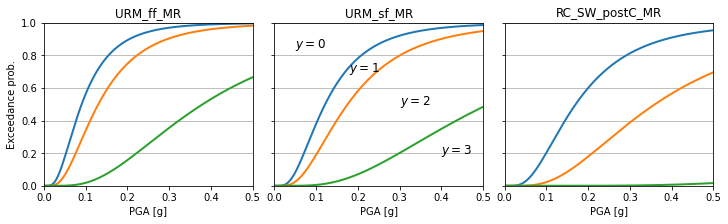

#### RMGP implementation

The object DamageEstimationModule collects the vulnerability function parameters $\boldsymbol{\eta}$ and $\boldsymbol{\beta}$. It transforms these parameters into a GPflow likelihood object that is used for inference using inspection data. Besides, it allows to generate sample of damage states $y\in\mathcal{Y}$ conditional on samples from $f(\mathbf{x})$. This is the second module of the RMGP.

```python
from CodePaper.rmgp.modules import DamageEstimationModule
DEM = DamageEstimationModule(etas, betas)
```

### Typological attribution module

The present model categorizes residential buildings in the case-study region into four unkown typological attribute combinations $a\in\mathcal{A}=\{1,2,3,4\}$:

- $a=1$ : Unreinforced masonry with flexible floors ('URM_ff')
- $a=2$ : Unreinforced masonry with stiff floors ('URM_sf')
- $a=3$ : Reinforced concrete shear wall ('RC_SW')
- $a=4$ : Reinforced concrete infill frame ('RC_INF')

These attribute combinations are modelled via four latent functions $\mathbf{g}$ that follow independent gaussian processes with an identical covariance function but different mean functions. Conditional on realizations from these four latent functions, the class membership probabilities $p(A=a|\mathbf{g},\mathbf{X})$ are calculated via the softmax function. Conditional on the sampled attribute combinations and the input information, we then map to the vulnerability types from above using a deterministic function. The following paragraphs walk you through the different parts of the model starting with the mean function.

#### Mean functions

The mean functions of the latent functions $\mathbf{g}$ are based on an expert-based attribution model that comes in the form of a conditional probability table. Specifically, the herein assumed model provides class membership probabilities conditional on five construction periods. The table is shown below.

|  | ConPeriod | p_URM_ff | p_URM_sf | p_RC_SW | p_RC_INF |
| --- | --- | --- | --- | --- | --- |
| 0 | cy $\leq$ 1900 | 1.00 | 0.00 | 0.00 | 0.0 |
| 1 | 1900 $<$ cy $\leq$ 1944 | 0.60 | 0.40 | 0.00 | 0.0 |
| 2 | 1944 $<$ cy $\leq$ 1969 | 0.25 | 0.60 | 0.15 | 0.0 |
| 3 | 1969 $<$ cy $\leq$ 1988 | 0.00 | 0.25 | 0.45 | 0.3 |
| 4 | cy $>$ 1988 | 0.00 | 0.10 | 0.60 | 0.3 |

We employ a smoothed version of this table via the introduction of sigmoid terms at the discrete boundaries of the different construction periods. The code below shows the formula and the figure illustrates the resulting functions.

```python
# Add a small value to zero entries and normalize such that the rows sum up to one
AttMat = df_am.iloc[:, 1:].values
AttMat[AttMat==0] += 0.001
AttMat = AttMat / np.sum(AttMat,axis=1).reshape(-1,1)

def mean_prior_prob_ta(df_target, AttMat):
    ca = AttMat.shape[1]
    Xm = np.zeros((len(df_target), ca))
    yb = df_target['const_year'].values
    for a in np.arange(ca):
        Xm[:, a] = (
            AttMat[0,a] +
            (AttMat[1,a]-AttMat[0,a]) * 1/(1+np.exp(-0.5*(yb-1900))) +
            (AttMat[2,a]-AttMat[1,a]) * 1/(1+np.exp(-0.5*(yb-1944))) +
            (AttMat[3,a]-AttMat[2,a]) * 1/(1+np.exp(-0.5*(yb-1969))) +
            (AttMat[4,a]-AttMat[3,a]) * 1/(1+np.exp(-0.5*(yb-1988))) )
    return Xm
```

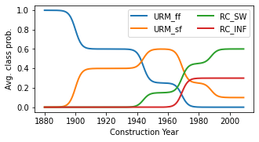

The mean functions $\mathbf{u}(\mathbf{x})$ of the four gaussian processes $\mathbf{g}$ are then the logarithmic probabilities shown in the above figure.

```python
def mean_fun_ta(df_target, AttMat):
    return np.log(mean_prior_prob_ta(df_target, AttMat))
```

#### Covariance function

The covariance function of the gaussian process is a combination of four individual functions. The first one ('v_ls') uses the spatial distance with a lengthscale of 5 km to account for long-scale spatial correlations. The second one ('v_ss') is the multiplication of three functions, using spatial distance (but with a shorter length-scale of 0.15 km) and similarites with respect to construction year and number of stories. The short-scale covariance function ('v_ss') adds additional correlation for buildings that are close, as well as of similar age and height.

```python
def k_sq(X1, X2, variance, lengthscale, dims):
    # Matrix of the squared euclidean distance between X1 and X2 in the specified dimensions (dims)
    sq_dist = np.sum(
        np.stack( [ (X1[:,dim].reshape(-1,1) - X2[:,dim].reshape(-1,1).T)**2 for dim in dims ] ),
        axis=0)
    return variance * np.exp(- sq_dist / (2*lengthscale**2))

def cov_fun_ta(dftarget):
    X1 = X2 = dftarget[['x', 'y', 'const_year', 'num_stories']].values
    v_ls = k_sq(X1, X2, 0.8, 5, [0, 1])
    v_ss = ( k_sq(X1, X2, 0.6, 0.15, [0, 1]) *
             k_sq(X1, X2, 0.6, 5, [2]) *
             k_sq(X1, X2, 0.6, 5, [3]) )
    return v_ls + v_ss
```

#### Deterministic mapping to vulnerability types

Mapping from the four unknown typological attribute combinations, $\mathcal{A}$, and the inputs, $\mathcal{X}$, to the 18 vulnerability types, $\mathcal{B}$, using the deterministic function $h$: $$h: \mathcal{A}\cup\mathcal{X} \mapsto \mathcal{B}$$ Specifically, we use the construction year to indicate whether a RC buildings was built prior or after the introduction of modern seismic provisions in building codes and the number of stories to categorize a building into the three height classes.

```python
def AssignVulClass(sim_a, df_target):
    num_story = df_target['num_stories'].values
    con_year = df_target['const_year'].values
    sim_b = 3 * sim_a
    # Separate height classes according to number of stories
    sim_b += (num_story<=2) * 0 + ((num_story>2) & (num_story<=5)) * 1 + (num_story>5) * 2
    # For RC buildings: Separate pre- and post-code buildings according to the construction year and
    # the introduction of modern seismic provisions in building codes.
    sim_b += ((sim_a >= 2) * (con_year > 1988)) * 6
    return sim_b.astype('int')
```

#### RMGP implementation

The object TypologyAttributionModule collects the functions explained above and initializes GPflow compatible kernel (covariance function), mean function and likelihood objects. This is the third, and final, module of the RMGP.

```python
from CodePaper.rmgp.modules import TypologyAttributionModule
col_names = ['x', 'y', 'const_year', 'num_stories']
TAM = TypologyAttributionModule(AttMat,
                          column_names = col_names,
                          column_dtypes = dfInput[col_names].dtypes,
                          func_assign_vul_class = AssignVulClass,
                          func_prior_mean_prob = mean_prior_prob_ta)

# To get the mean vectors:
u = TAM.mean_func(dfInput.iloc[:5])
# To get the covariance matrix:
V = TAM.cov_func(dfInput.iloc[:5])
```

#### Example

We illustrate the typological attribution model on following toy example consisting of five buildings. As shown below, buildings 0, 1 and 3 are close to each other, whereas their distance to buildings 2 and 4 is 2km and 10km respectively. Note also the similarities and differences in the construction year ('GBAUJ') and the number of stories.

```
       x    y  const_year  num_stories
0   0.00  0.0        1918            2
1   0.05  0.0        1920            3
2   2.00  0.0        1995            4
3   0.06  0.0        1995            9
4  10.00  0.0        1925            2
```

First, evaluate the mean functions $\mathbf{u}(\mathbf{x})$ of the typological distribution model evaluated on the inputs of those five buildings. The left plot below shows in each column the mean vector $\mathbf{u}^{(a)}$ for the different typological attribute combinations $a\in\mathcal{A}$. The right plot shows the exponentiated mean vectros, which correspond to the average class probabilities shown in the Figure above. Because these class probabilities only depend on the construction year, values for buildings 0, 1 and 4 are identical (i.e. 60\% probability for URM_ff).

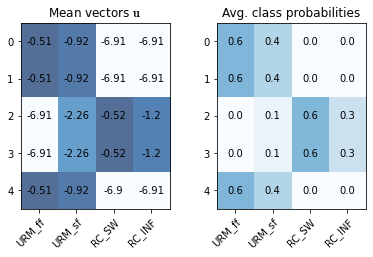

Whereas the mean functions of the four GPs differ, their covariance function $v(\mathbf{x},\mathbf{x}')$ is the same. We illustrate first the covariance matrix resulting from an evaluation of the large-scale covariance function ($v_{ls}$) at the input points of the five buildings. Because building 4 is further away from the remaining buildings, its correlation (i.e. the off-diagonal terms) are small.

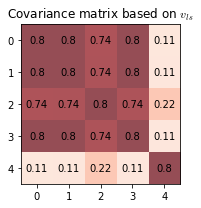

The following figure shows the covariance matrices resulting from an evaluation of the small-scale covariance functions ($v_{ss,1}$, $v_{ss,2}$, $v_{ss,3}$) at the input points of the five buildings.

First, $v_{ss,1}$ assigns high correlation (the off-diagonal terms) within the three buildings that are close to each other. Second, $v_{ss,2}$ assigns decreasing correlations with increasing difference in the construction year. Third, $v_{ss,3}$ assigns decreasing correlations with increasing difference in the the number of stories.

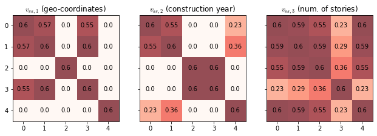

The multiplicative structure of the short-scale covariance function yields a covariance matrix where only buildings 0 and 1 are partially correlated and the others are uncorrelated. This follows from an element-wise multiplication of three matrices illustrated above.

Finally, the combined covariance matrix $v=v_{ls}+v_{ss}$ is shown below. We observe particularly high off-diagonal terms for the first two buildings. For building 4, which is located roughly 10km away from the others, the correlation is small.

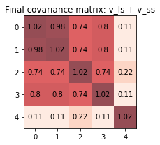

The four latent functions evaluated on the input points of the five buildings result in four multivariate normal distributions, which have the same covariance matrix but different mean vectors. Now, we generate one sample from each of these distributions. This is illustrated in the left plot below. We see that especially for the highly correlated buildings 0 and 1 the sampled function values are very similar.

Subsequently, we apply the softmax function to derive class-membership probabilities: $$ p(A_i=a|\mathbf{g}_i) = \frac{\exp g_i^{(a)}}{\sum_j \exp g_i^{(j)}} $$ The resulting sampled class membership prob. are shown in the right plot.

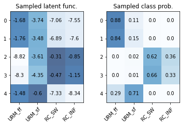

These sampled class membership probabilities are then used to sample an attribute combination $a\in\mathcal{A}$ for each building independently, and subsequently allocate a vulnerability type $b\in\mathcal{B}$ using the deterministic function above. The next section presents the code for the entire simulation workflow.

### RMGP Implemenation

The RMGP object combines the three modules explained above and takes the event characteristics as an additional input. This object is used for prediction and inference using data from seismic stations and building inspections. The inference workflow is explained in the example notebook in the GitLab repository, while the simulation workflow is illustrated below.

```python
from CodePaper.rmgp.model import RMGP
rmgp = RMGP(SpGMM, TAM, DEM, EC)
```

## Simulation workflow

The code below illustrates the simulation workflow for 'numB' buildings and 'numSim' simulations. Here we randomly sample 'numB' buildings from the entire building stock. For the results presented in the paper, this simulation workflow is applied to all buildings of a given subregion, and then repeated for each subregion. Again, a step-by-step numpy implementation is presented first and in the end the procedure is illustrated with the RMGP implementation.

```python
numB = 100
numSim = 10
dftarget = dfInput[['x', 'y', 'SoilClass', 'const_year', 'num_stories']].sample(n=numB)
```

First, sample from the GP function $f$ (logarithm of peak ground acceleration), 'numSim' values at the 'numB' locations of all buildings. Result is a matrix of size ('numSim' x 'numB').

```python
mean_vector_f = mean_fun_im(dftarget, EC, T)
cov_matrix_f = cov_fun_gm(dftarget, corr_length, T)
sample_f = np.random.multivariate_normal(mean_vector_f, cov_matrix_f, numSim)
```

Second, sample from the GP functions g (typological attribution), 'numSim' values for the 'numB' buildings. Result is a matrix of size ('numSim' x 'numB' x 4), because we consider four unkown attribute combinations.

```python
mean_vectors_g = mean_fun_ta(dftarget, AttMat)
cov_matrix_g = cov_fun_ta(dftarget)
sample_g = []
for i in np.arange(4):
    sample_g.append(np.random.multivariate_normal(mean_vectors_g[:,i], cov_matrix_g, numSim))
sample_g = np.stack(sample_g, axis=-1)
```

Third, apply the softmax function to the samples of g to derive the conditional class membership probabilities $p(A=a|\mathbf{g})$. Then, sample a value $a\in\mathcal{A}$ from these categorical distributions. Result is a matrix of size ('numSim' x 'numB').

```python
p_a = np.exp(sample_g) / np.sum(np.exp(sample_g), axis=-1)[:,:,None]
cdf_a = np.cumsum( np.append(np.zeros((numSim,numB,1)), p_a, axis=-1), axis=-1)
sam_a = np.zeros((numSim,numB))
rnd_uni = np.random.uniform(0, 1, sam_a.shape)
for i in np.arange(4):
    sam_a[(rnd_uni > cdf_a[:,:,i]) & (rnd_uni <= cdf_a[:,:,i+1])] = i
```

Fourth, apply the deterministic mapping from the sampled typological attribute combinations $a$ to the vulnerability types $b$. Result is a matrix of size ('numSim' x 'numB').

```python
sam_b = AssignVulClass(sam_a, dftarget)
```

Fifth, use the sampled vulnerability types $b$ to choose the vulnerability function and we calculate for each damage state, sample and building a cumulative probability $p(Y\leq y|f,b)$. Then, sample a value $y\in\mathcal{Y}$ from these categorical distributions. Result is a matrix of size ('numSim' x 'numB').

```python
cdf_y = []
for i in np.arange(3):
    cdf_y.append(1 - norm.cdf( (sample_f - etas[sam_b, i]) / betas[sam_b,0] ) )
cdf_y = np.stack(cdf_y, axis=-1)
cdf_y = np.concatenate([np.zeros((numSim,numB,1)), cdf_y, np.ones((numSim,numB,1))],axis=-1)
sam_y = np.zeros((numSim, numB))
rnd_uni = np.random.uniform(0, 1, sam_y.shape)
for i in np.arange(4):
    sam_y[(rnd_uni > cdf_y[:,:,i]) & (rnd_uni <= cdf_y[:,:,i+1])] = i
```

Aggregate buildings with the same damage state. This results in 'numSim' vectors indicating how many of the 'numB' buildings are in each damage state $y\in\mathcal{Y}$. For simulation run $j$, this vector of building counts per damage state is denoted as $\mathbf{n}_j$ in the paper.

```python
sam_n = np.apply_along_axis(lambda x: np.bincount(x, minlength = 4),
                                               axis=1, arr=sam_y.astype('int')).T
```

#### RMGP Implementation

The RMGP combines the individual steps outlined above and the simulation of 'numSim' vectors $\mathbf{n}_j$ is obtained with one line of code.

```python
sam_n = rmgp.Sample_damage(dftarget, numSim, aggregate=True).T
```

The figure below shows vectors $\mathbf{n}_j$ for ten simulation runs $j\in (1,2,...,10)$.

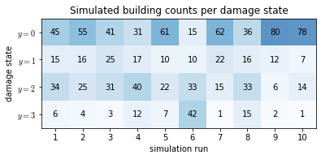

The workflow above would be applied in the absence of any further post-earthquake data. In the paper, however, we use data from seismic recordings (available in the immediate aftermath of the event) and later also data from building inspections using the object-oriented and GPflow compatible RMGP implementation of the risk model.

## Error metrics

We use the simulated building counts from above to illustrate the error metrics used in the paper. Following "true" building counts per damage state $\check{\mathbf{n}} = [65, 25, 8, 2]$ are assumed.

Note that here we only performed 10 simulation runs, whereas for the results presented in the paper we used 10'000 runs.

### Marginal Prediction Error (MPE)

The marginal prediction error, as defined in the paper, is calculated as the continuous ranked probability score (CRPS). For a specific damage state $y$, we evaluate the marginal prediction error as: $$ \mathrm{MPE}_{y}\hat{=}\mathrm{CRPS}(p(N_{y});\check{n}_{y}) \approx \frac{1}{r} \sum_{j=1}^{r} \left( || n_{yj} - \check{n}_{y} ||_2 - \frac{1}{2r} \sum_{i=1}^{r} || n_{yj} - n_{yi} ||_2 \right) $$

The first term within the sum of the MPE formulation measures the bias of the predictions. Note that the euclidean distance in one dimension is equivalent to the absolute difference. Thus, for each simulation run $j$, the first term measures the absolute error with respect to the true number of buildings in that damage category, $\check{n}_{y}$. This is shown in the first row of the following plot for damage state $y=1$.

```python
true_vals = np.array([65, 25, 8, 2])
term_1 = np.abs(sam_n[1,:] - true_vals[1])
```

The second term of the MPE accounts for the dispersion. For each simulation run $j$ it measures the average absolute difference to all simulation runs, which is then multiplied by 0.5. This is shown in the second row of the following plot for damage state $y=1$.

```python
term_2 = np.stack([1/(2*numSim) * np.sum(np.abs(sam_n[1,i] - sam_n[1,:]))
                   for i in np.arange(numSim)])
```

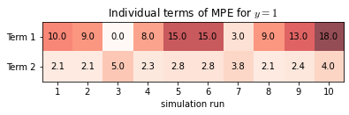

The MPE is then calculated via subtracting the second term from the first term, and taking the average of this result over all $r$ simulation runs.

```python
np.mean(term_1 - term_2)
```

```
7.06
```

### Joint Prediction Error (JPE)

The joint prediction error, as defined in the paper, is calculated as the energy score (ES). The ES is the generalization of the continuous ranked probability score to multivariate distributions and is defined as: $$ \mathrm{JPE} \ \hat{=} \ \mathrm{ES}(p(\mathbf{N});\check{\mathbf{n}}) \approx \frac{1}{r} \sum_{j=1}^{r} \left( || \mathbf{n}_{j} - \check{\mathbf{n}} ||_2 - \frac{1}{2r} \sum_{i=1}^{r} || \mathbf{n}_{j} - \mathbf{n}_{i} ||_2 \right) $$ This definition closely resembles the definition of the MPE, except that the scalar values $n_{y,j}$ and $\check{n}_{y}$ are replaced by vectors $\mathbf{n}_{j}$ and $\check{\mathbf{n}}$.

The first term within the sum sign measures the euclidean distance between the simulated damage state counts $\mathbf{n}_{j}$ in run $j$ and the true damage state counts $\check{\mathbf{n}}$. The euclidean distance is measured in a four-dimensional space, since we consider four damage states.

The second term measures the average euclidean distance from the simulated damage state counts $\mathbf{n}_{j}$ to the damage state counts of all simulation runs, which is then multiplied by 0.5.

Both terms are illustrated in the figure below for each simulation run.

```python
term_1 = np.linalg.norm(sam_n - true_vals[:,None], axis=0)
term_2 = np.stack([1/(2*numSim) * np.sum(np.linalg.norm(sam_n[:,i][:,None] -
                                      sam_n, axis=0)) for i in np.arange(numSim)])
```

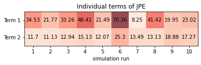

The JPE is then calculated via subtracting the second term from the first term, and taking the average of this result over all $r$ simulation runs.

```python
np.mean(term_1 - term_2)
```

```
17.14174151961229
```